# FigureYa301scCoExpr

**Author(s)**: Xiao Gu  
**Reviewer(s)**: Ying Ge, Yasi Zhang  
**Date**: 2025-11-25

## 1 Academic Citation

If you use this code in your work or research, we kindly request that you cite our publication:

Xiaofan Lu, et al. (2025). FigureYa: A Standardized Visualization Framework for Enhancing Biomedical Data Interpretation and Research Efficiency. iMetaMed. https://doi.org/10.1002/imm3.70005

## 2 需求描述 Demand description

用来展示单细胞的基因共表达。用2种颜色分别映射2个基因的表达量/连续变量，然后merge展示，有点像免疫荧光实验的merge效果，颜色不是固定值，映射到连续性表达量的也是渐变色。

Used to display gene co-expression in single cells. Two colors are used to map the expression levels/continuous variables of two genes, which are then merged for display, similar to the merge effect in immunofluorescence experiments. The colors are not fixed values but are mapped to continuous expression levels as gradients.

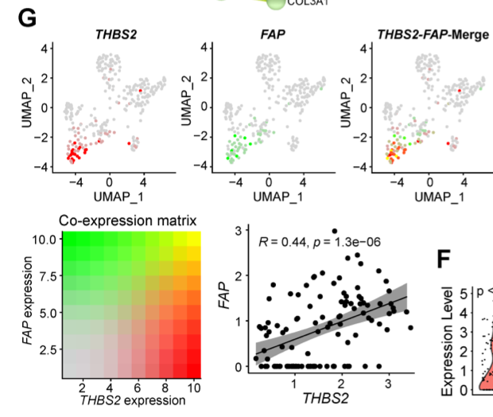

Figure 5. scRNA-seq analysis reveals subsets of CAFs as the major source of THBS2 production.

G, UMAP plots showing the co-expression of THBS2 and FAP across individual single CAFs. Red/green dots represent CAFs expressing THBS2+ only/FAP+ only (upper left/middle panels), respectively, and yellow dots indicate CAFs co-expressing THBS2 and FAP only (upper right panel); lower left panel showing the **co-expression matrix** across CAFs with different expression of FAP and THBS2; lower right panels showing the **correlation (Pearson)** between THBS2 and FAP across THBS2+ CAFs. (1) Strong correlation: Pearson’s r ≥ 0.8; (2) Moderate: 0.5 ≤ Pearson’s r < 0.8; (3) Weak: 0.3 ≤ Pearson’s r < 0.5; (4) No correlation: Pearson’s r < 0.3). The darker the color, the higher the expression level of the indicated markers. Of note, only a minority of CAFs co-express high THBS2 and FAP.

From https://www.thno.org/v12p3104.htm

## 3 应用场景 Application scenarios

展示单细胞的基因共表达，以及共表达基因相关性。

Displaying gene co-expression in single cells and the correlation of co-expressed genes.

## 4 环境设置 Environment Setup

```r
source("install_dependencies.R")
```

```
## Starting R package installation...
## ===========================================
##
## Installing CRAN packages...
## Package already installed: ggplot2
## Package already installed: magrittr
## Package already installed: patchwork
## Package already installed: ggpubr
## Package already installed: Seurat
##
## Installing SeuratData from GitHub...
## Package already installed: SeuratData
## pbmc3k.SeuratData package already installed.
##
## Package installation completed!
## You can now run your R scripts in this directory.
```

```r
library(Seurat) # 单细胞数据处理 Single-cell data processing
library(SeuratData) # 单细胞数据集 SeuratData
library(ggplot2) # 绘图 Plotting
library(ggpubr) # 配色 Plotting
library(patchwork) # 拼图 Plotting
library(magrittr) # 数据处理 Data processing

Sys.setenv(LANGUAGE = "en") # 显示英文报错信息 # Show English error messages
options(stringsAsFactors = FALSE) # 禁止chr转成factor # Prevent character-to-factor conversion
```

## 5 输入文件预处理 Data Preprocessing

使用最常用的SeuratData中的pbmc3k进行演示。

Demonstration using the pbmc3k dataset from the widely adopted SeuratData package.

```r
# InstallData("pbmc3k")
# 加载数据集
# load dataset
LoadData("pbmc3k")
```

```
## Validating object structure
```

```
## Updating object slots
```

```
## Ensuring keys are in the proper structure
```

```
## Ensuring keys are in the proper structure
```

```
## Ensuring feature names don't have underscores or pipes
```

```
## Updating slots in RNA
```

```
## Validating object structure for Assay 'RNA'
```

```
## Object representation is consistent with the most current Seurat version
```

```
## An object of class Seurat
## 13714 features across 2700 samples within 1 assay
## Active assay: RNA (13714 features, 0 variable features)
##  2 layers present: counts, data
```

```r
pbmc3k <- UpdateSeuratObject(pbmc3k)
```

```
## Validating object structure
```

```
## Updating object slots
```

```
## Ensuring keys are in the proper structure
```

```
## Updating matrix keys for DimReduc 'pca'
```

```
## Updating matrix keys for DimReduc 'umap'
```

```
## Ensuring keys are in the proper structure
```

```
## Ensuring feature names don't have underscores or pipes
```

```
## Updating slots in RNA
```

```
## Updating slots in RNA_nn
```

```
## Setting default assay of RNA_nn to RNA
```

```
## Updating slots in RNA_snn
```

```
## Setting default assay of RNA_snn to RNA
```

```
## Updating slots in pca
```

```
## Updating slots in umap
```

```
## Setting umap DimReduc to global
```

```
## Setting assay used for NormalizeData.RNA to RNA
```

```
## Setting assay used for FindVariableFeatures.RNA to RNA
```

```
## Setting assay used for ScaleData.RNA to RNA
```

```
## Setting assay used for RunPCA.RNA to RNA
```

```
## Setting assay used for JackStraw.RNA.pca to RNA
```

```
## No assay information could be found for ScoreJackStraw
```

```
## Setting assay used for FindNeighbors.RNA.pca to RNA
```

```
## No assay information could be found for FindClusters
```

```
## Setting assay used for RunUMAP.RNA.pca to RNA
```

```
## Validating object structure for Assay 'RNA'
```

```
## Validating object structure for Graph 'RNA_nn'
```

```
## Validating object structure for Graph 'RNA_snn'
```

```
## Validating object structure for DimReduc 'pca'
```

```
## Validating object structure for DimReduc 'umap'
```

```
## Object representation is consistent with the most current Seurat version
```

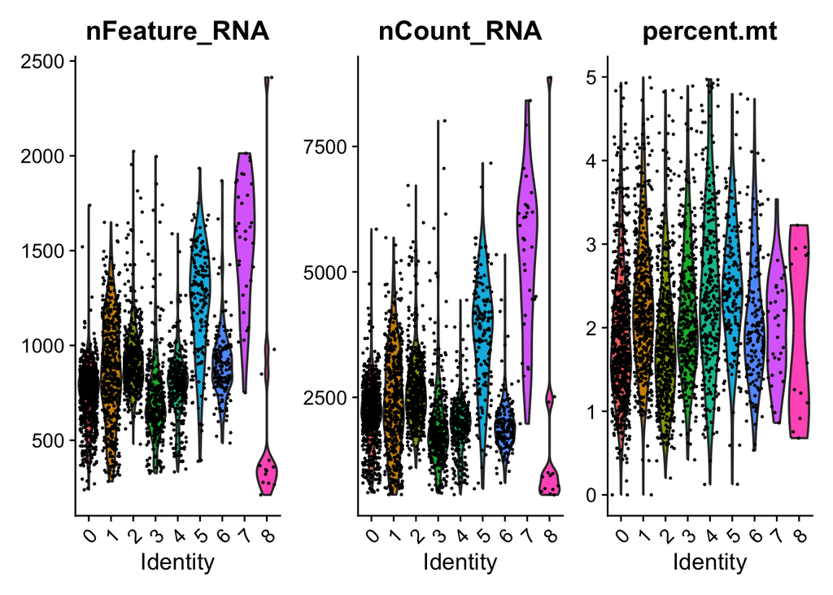

```r
# 计算线粒体基因比例
# Calculate mitochondrial gene percentage
pbmc3k[["percent.mt"]] <- PercentageFeatureSet(pbmc3k, pattern = "^MT-")

# 质控数据可视化
# Quality control visualization
VlnPlot(pbmc3k, features = c("nFeature_RNA", "nCount_RNA", "percent.mt"), ncol = 3)
```

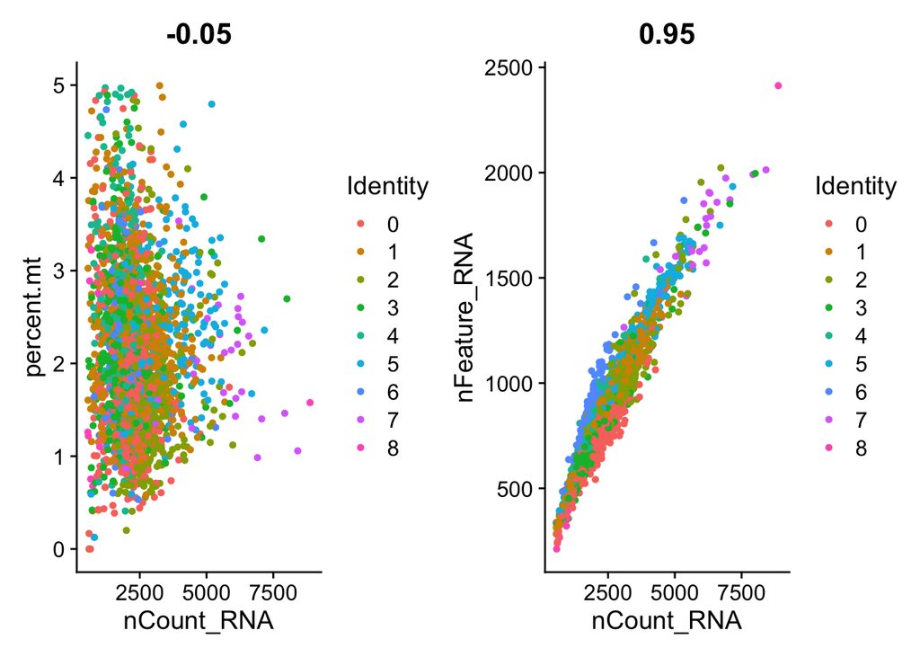

```r
plot1 <- FeatureScatter(pbmc3k, feature1 = "nCount_RNA", feature2 = "percent.mt")
plot2 <- FeatureScatter(pbmc3k, feature1 = "nCount_RNA", feature2 = "nFeature_RNA")
plot1 + plot2
```

```r
# 通过控制基因数和线粒体基因比例过滤掉低质量细胞，过滤完后剩余2638
# Filter low-quality cells by controlling gene counts and mitochondrial percentage, retaining 2,638 cells after filtering
pbmc3k <- subset(pbmc3k, subset = nFeature_RNA > 200 & nFeature_RNA < 2500 & percent.mt < 5)
pbmc3k
```

```
## An object of class Seurat
## 13714 features across 2638 samples within 1 assay
## Active assay: RNA (13714 features, 2000 variable features)
##  3 layers present: counts, data, scale.data
##  2 dimensional reductions calculated: pca, umap
```

```r
# 进行normalize并计算高变异基因
# Normalize data and identify highly variable genes
pbmc3k <- NormalizeData(pbmc3k, normalization.method = "LogNormalize", scale.factor = 10000)
pbmc3k <- FindVariableFeatures(pbmc3k, selection.method = "vst", nfeatures = 2000)

# Scale数据
# Scale data
all.genes <- rownames(pbmc3k)
pbmc3k <- ScaleData(pbmc3k, features = all.genes)
# 进行主成分分析
# PCA
pbmc3k <- RunPCA(pbmc3k, features = VariableFeatures(object = pbmc3k))
```

```
## PC_ 1
## Positive:  CST3, TYROBP, LST1, AIF1, FTL, FTH1, LYZ, FCN1, S100A9, TYMP
##     FCER1G, CFD, LGALS1, S100A8, CTSS, LGALS2, SERPINA1, IFITM3, SPI1, CFP
##     PSAP, IFI30, SAT1, COTL1, S100A11, NPC2, GRN, LGALS3, GSTP1, PYCARD
## Negative:  MALAT1, LTB, IL32, IL7R, CD2, B2M, ACAP1, CD27, STK17A, CTSW
##     CD247, GIMAP5, AQP3, CCL5, SELL, TRAF3IP3, GZMA, MAL, CST7, ITM2A
##     MYC, GIMAP7, HOPX, BEX2, LDLRAP1, GZMK, ETS1, ZAP70, TNFAIP8, RIC3
## PC_ 2
## Positive:  CD79A, MS4A1, TCL1A, HLA-DQA1, HLA-DQB1, HLA-DRA, LINC00926, CD79B, HLA-DRB1, CD74
##     HLA-DMA, HLA-DPB1, HLA-DQA2, CD37, HLA-DRB5, HLA-DMB, HLA-DPA1, FCRLA, HVCN1, LTB
##     BLNK, P2RX5, IGLL5, IRF8, SWAP70, ARHGAP24, FCGR2B, SMIM14, PPP1R14A, C16orf74
## Negative:  NKG7, PRF1, CST7, GZMB, GZMA, FGFBP2, CTSW, GNLY, B2M, SPON2
##     CCL4, GZMH, FCGR3A, CCL5, CD247, XCL2, CLIC3, AKR1C3, SRGN, HOPX
##     TTC38, APMAP, CTSC, S100A4, IGFBP7, ANXA1, ID2, IL32, XCL1, RHOC
## PC_ 3
## Positive:  HLA-DQA1, CD79A, CD79B, HLA-DQB1, HLA-DPB1, HLA-DPA1, CD74, MS4A1, HLA-DRB1, HLA-DRA
##     HLA-DRB5, HLA-DQA2, TCL1A, LINC00926, HLA-DMB, HLA-DMA, CD37, HVCN1, FCRLA, IRF8
##     PLAC8, BLNK, MALAT1, SMIM14, PLD4, P2RX5, IGLL5, LAT2, SWAP70, FCGR2B
## Negative:  PPBP, PF4, SDPR, SPARC, GNG11, NRGN, GP9, RGS18, TUBB1, CLU
##     HIST1H2AC, AP001189.4, ITGA2B, CD9, TMEM40, PTCRA, CA2, ACRBP, MMD, TREML1
##     NGFRAP1, F13A1, SEPT5, RUFY1, TSC22D1, MPP1, CMTM5, RP11-367G6.3, MYL9, GP1BA
## PC_ 4
## Positive:  HLA-DQA1, CD79B, CD79A, MS4A1, HLA-DQB1, CD74, HIST1H2AC, HLA-DPB1, PF4, SDPR
##     TCL1A, HLA-DRB1, HLA-DPA1, HLA-DQA2, PPBP, HLA-DRA, LINC00926, GNG11, SPARC, HLA-DRB5
##     GP9, AP001189.4, CA2, PTCRA, CD9, NRGN, RGS18, CLU, TUBB1, GZMB
## Negative:  VIM, IL7R, S100A6, IL32, S100A8, S100A4, GIMAP7, S100A10, S100A9, MAL
##     AQP3, CD2, CD14, FYB, LGALS2, GIMAP4, ANXA1, CD27, FCN1, RBP7
##     LYZ, S100A11, GIMAP5, MS4A6A, S100A12, FOLR3, TRABD2A, AIF1, IL8, IFI6
## PC_ 5
## Positive:  GZMB, NKG7, S100A8, FGFBP2, GNLY, CCL4, CST7, PRF1, GZMA, SPON2
##     GZMH, S100A9, LGALS2, CCL3, CTSW, XCL2, CD14, CLIC3, S100A12, RBP7
##     CCL5, MS4A6A, GSTP1, FOLR3, IGFBP7, TYROBP, TTC38, AKR1C3, XCL1, HOPX
## Negative:  LTB, IL7R, CKB, VIM, MS4A7, AQP3, CYTIP, RP11-290F20.3, SIGLEC10, HMOX1
##     LILRB2, PTGES3, MAL, CD27, HN1, CD2, GDI2, CORO1B, ANXA5, TUBA1B
##     FAM110A, ATP1A1, TRADD, PPA1, CCDC109B, ABRACL, CTD-2006K23.1, WARS, VMO1, FYB
```

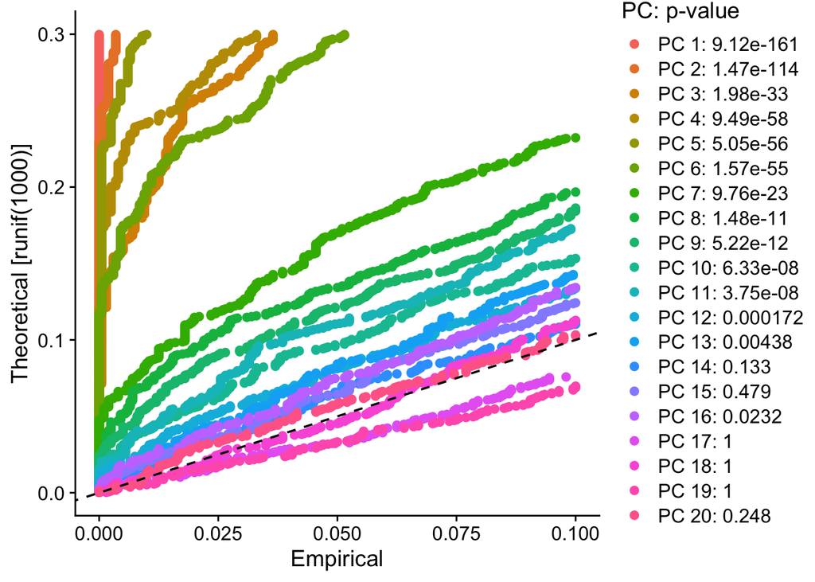

```r
#DimHeatmap(pbmc3k, dims = 1:30, cells = 500, balanced = TRUE)
pbmc3k <- JackStraw(pbmc3k, num.replicate = 100)
pbmc3k <- ScoreJackStraw(pbmc3k,dims = 1:20)
JackStrawPlot(pbmc3k, dims = 1:20)
```

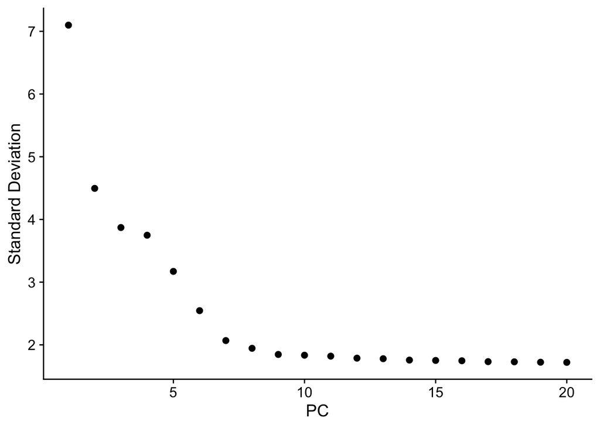

```r
ElbowPlot(pbmc3k)
```

```r
# 选择前10个pc基因降维
# Dimensionality reduction using top 10 PCs
npcs = 1:10
pbmc3k <- FindNeighbors(pbmc3k, dims = npcs)
pbmc3k <- FindClusters(pbmc3k, resolution = 0.5)
```

```
## Modularity Optimizer version 1.3.0 by Ludo Waltman and Nees Jan van Eck
##
## Number of nodes: 2638
## Number of edges: 95927
##
## Running Louvain algorithm...
## Maximum modularity in 10 random starts: 0.8728
## Number of communities: 9
## Elapsed time: 0 seconds
```

```r
pbmc3k <- RunUMAP(pbmc3k, dims = 1:10)
```

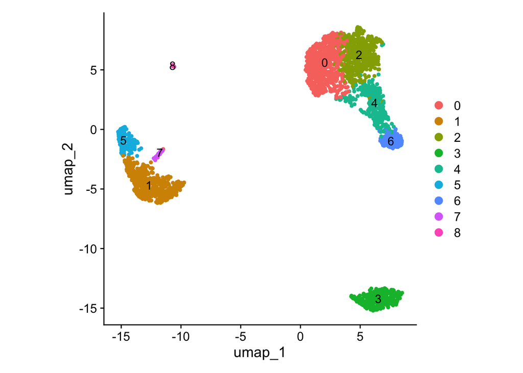

```r
DimPlot(pbmc3k, reduction = "umap", label = T, pt.size = 1,raster = F)+
  theme(aspect.ratio = 1)
```

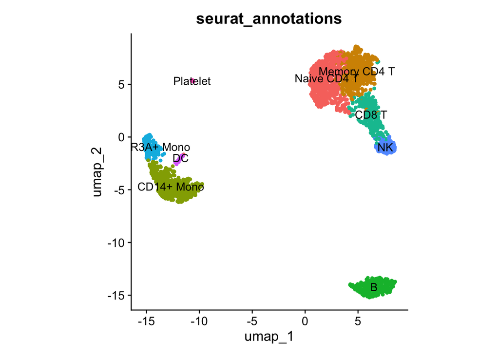

```r
DimPlot(pbmc3k, reduction = "umap", group.by = "seurat_annotations",label = T, pt.size = 1,raster = F)+
  theme(aspect.ratio = 1)+
  NoLegend()
```

```r
#save(pbmc3k, file = "./pbmc3k_anno_CellType.rdata")
```

## 6 开始画图 Plotting

选择CD3G和CD247这两个T细胞marker基因进行基因共表达可视化

Visualizing gene co-expression of T-cell marker genes CD3G and CD247

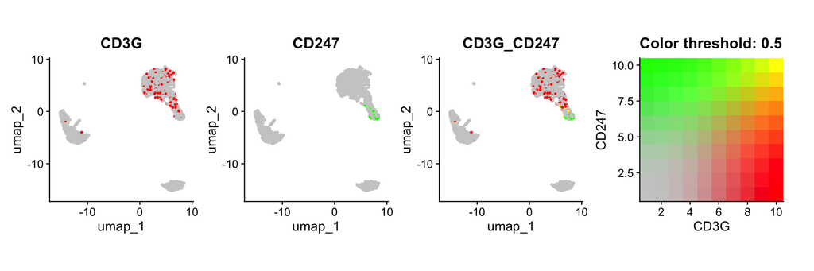

```r
# FeaturePlot绘制UMAP图上共表达基因展示，blend设置为TRUE
# FeaturePlot for co-expression visualization on UMAP,and blend is set to TRUE
FeaturePlot(pbmc3k, features = c("CD3G", "CD247"),
            blend = TRUE,
            cols = c("gray80","red", "green"),
            pt.size = 0.5, raster = F) +
  theme(aspect.ratio = 1)
```

```r
ggsave("UMAP_co-expression matrix.pdf", width = 12, height = 4)
```

自定义函数，用于计算共表达基因相关性并可视化

Custom function for calculating and visualizing co-expression gene correlation

```r
# object: seurat对象
# gene1和gene2: 两个共表达基因名
# cor.method: 计算各相关性方法，可选spearman或pearson,
# jitter.num: 为了防止所有数据聚集在一起，jitter.num使数据进行轻微抖动，设置为0则为原始数据绘图，
# pos: 若为TRUE，怎只使用两个基因都表达的细胞计算相关性，可避免好多细胞中对其中一个细胞表达量为0

# object: Seurat object
# gene1 & gene2: Names of two co-expressed genes
# cor.method: Correlation method ("spearman" or "pearson")
# jitter.num: Adds slight jitter to prevent data clustering (set to 0 for raw data plotting)
# pos: If TRUE, only uses cells expressing both genes to avoid zero-expression bias

getScatterplot <- function(object, gene1, gene2, cor.method = "spearman",
                           jitter.num = 0.15, pos = TRUE){
  if (!gene1 %in% rownames(object)) {
    print("gene1 was not found")
    if (!gene2 %in% rownames(object)) {
      print("gene2 was not found")
    }
  }else{
    exp.mat <- GetAssayData(object = object, assay = "RNA") %>% .[c(gene1,gene2),] %>%
      as.matrix() %>% t() %>% as.data.frame()
    if (pos) {
      exp.mat <- exp.mat[which(exp.mat[,1] > 0 & exp.mat[,2] > 0),]
    }
    plots <- ggplot(data=exp.mat, mapping = aes_string(x = gene1, y = gene2)) +
      geom_smooth(method = 'lm', se = T, color='red', size=1)+
      stat_cor(method = cor.method)+
      geom_jitter(width = jitter.num, height = jitter.num, color = "black", size = 1, alpha=1)+
      theme_bw()+
      theme(panel.grid=element_blank(),
            legend.text=element_text(colour= 'black',size=10),
            axis.text= element_text(colour= 'black',size=10),
            axis.line= element_line(colour= 'black'),
            panel.border = element_rect(size = 1, linetype = "solid", colour = "black"),
            panel.background=element_rect(fill="white"))
    return(plots)
  }
}
```

计算共表达基因相关性，并可视化

Calculate Co-expression Gene Correlation and Visualize

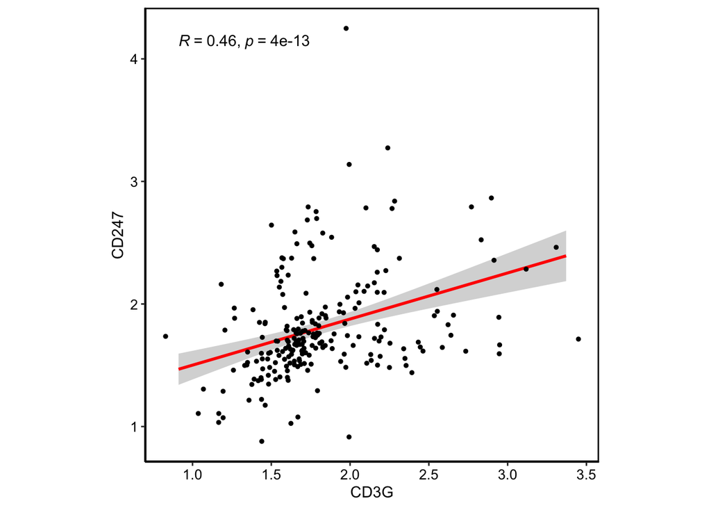

```r
# 设置抖动参数，防止数据聚集在一起 Setting jitter parameter to prevent data clustering
getScatterplot(pbmc3k, gene1 = "CD3G", gene2 = "CD247",
               jitter.num = 0.15, pos = TRUE) +
  theme(aspect.ratio = 1)
```

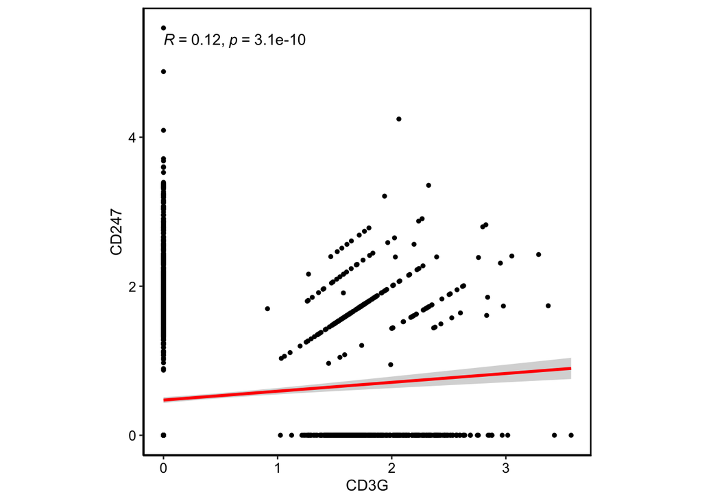

```r
ggsave("correlation_dotplot.pdf")
# 不添加抖动，显示原始数据位置 No jitter, display original data position
getScatterplot(pbmc3k, gene1 = "CD3G", gene2 = "CD247",
               jitter.num = 0, pos = FALSE) +
  theme(aspect.ratio = 1)
```